# Tundra Light Extinction Model

Ruby An

2024-01-12

# 1 Introduction

This document describes a multi-species model of tundra plant community dynamics. The goals of this model are to:

1. explain the coexistence of multiple species in tundra plant communities, and
2. make predictions about community-level outcomes in a changing climate.

Our approach is to build a simple model informed by the physical structure, demographic processes, and resource requirements common to plant species in tundra environments. We characterize equilibrium dynamics of the model and establish criterion for species coexistence as a function of species’ traits.

We then test how environmental change (warming, longer growing seasons, higher nutrient availability) alters competitive outcomes through a series of simulations. Environmental conditions alter outcomes by impacting species’ growth rates, time available for growth, and mortality risk.

# 2 Model Description

This model tracks the density of ramets ($N_{i}$ – the number of individual ramets of species $i$ in a given unit area) in continuous time.

For ease of notation, we order species from tallest to shortest ramet height:

$$H_{1} > H_{2} > \cdots > H_{j}
> H_{i} > \cdots > H_{Q} \text{ for species } i = 1, 2, ...,
Q$$
In this imagination of the tundra world, ramets never “grow in height”, but are instantaneously born at their species-specific height once a “mother ramet” has accumulated enough carbon. This means that each species occupies only one specific height $H_i$ in the canopy at any given point in time. This simplifies the description of the light environment, such that we are able to easily calculate equilibrium environmental conditions, ramet densities, and coexistence criterion.

## 2.1 Ramet Allometry

Ramet biomass is related allometrically to height, via the following powerlaw.

$$B_i = b H_i^\beta$$

where $b$ is a biomass conversion parameter (e.g. wood density). For forest tree systems from which this model draws inspiration, $\beta = 5$ is typical, since

$$\begin{align}
B &= \text{height * basal area} \\
& H \propto D^{1/2} \text{ and } \text{basal area} \propto D^2 \\
& \Rightarrow B \propto D^{5/2} \text{ i.e. } B \propto H^5
\end{align}$$

We fix ramet crown area to be equal for all species.

$$C_i = C_j = c, \quad \forall i,j$$

## 2.2 Ramet Carbon Economy

Carbon gain per ramet is determined by light availability. When exposed to a given light level ($L_{R_i}$), ramets gain carbon through photosynthesis ($A(L_{R_i})$) and lose carbon due to respiration and maintenance costs ($r$). The carbon accumulation rate of a ramet of species $i$ when exposed to light level $L_{R_i}$, is given by:

$$g_i(L_{R_i}) = A(L_{R_i}) - r$$
$A(L_{R_i})$ is a function describing photosynthesis per ramet. For now, we assume that photosynthesis is a linear function of light availability.

$$A(L_{R_i}) = a L_{R_i}$$
where $a$ is the rate of carbon gain per ramet. Carbon losses $r$ include leaf respiration and construction costs (i.e. 1 / leaf turnover rate).

*NOTE:* For now, we assume $a$ and $r$ are fixed parameters equal for all species. Since crown area is the same across species, I write the physiological parameters $a$ and $r$ to be rates as carbon gain or loss . In further models, I may rewrite to explicity include species specific crown area. In this case, these physiological rates would be written per unit leaf area.

## 2.3 Ramet Demography

Once a ramet accumulates carbon equivalent to its species-specific biomass ($B_i$), it produces a full-size daughter ramet. This means reproduction is not continuous, but pulsed at a certain interval per species.

Based on our description of ramet allometry and physiology, we can write an expression for the time required until reproduction ($T_i$),

$$T_i = \frac{B_i}{g_i(L_{R_i})}$$
This value sets the fecundity (birth rate per unit time) of a species. At equilibrium, $T_i$ is a fixed value.

## 2.4 Light Competition and Environment

The first version of this model includes only competition for light, assuming light extinction following Beer’s law.

$L_{R_i}$ is the light experienced by a single ramet of species $i$.

## 2.5 Light requirement at equlibrium

## 2.6 Light requirement for establishment

## 2.7 EQ density with light requirement as a continous trait

# 3 Simulations

## 3.1 Parameters

```
## <environment: R_GlobalEnv>
```

| parameter | value | description | unit |
| --- | --- | --- | --- |
| a | 2.0 | rate of photosynthesis | NA |
| r_l | 0.3 | rate of respiration | NA |
| c_l | 0.3 | cost of construction | NA |
| b | 0.5 | biomass density | NA |
| k | 0.2 | light decay coefficient | NA |
| v | 10.0 | leaf area per ramet | NA |
| beta | 5.0 | height to mass power | NA |
| m | 2.0 | ramet mortality | NA |

## 3.2 Light required for establishment

The biomass of a ramet increases in proportion to height to the 5th power. This means that the taller the species, the longer it will take a ramet to accumulate enough carbon to reproduce. We can plot the “light required for a species of height x” to invade from rare, e.g. lifetime reproductive success > 0 assuming no other ramets of the same species, as given below.

This means that the light must be AT LEAST this level in order for the ramet to invade.

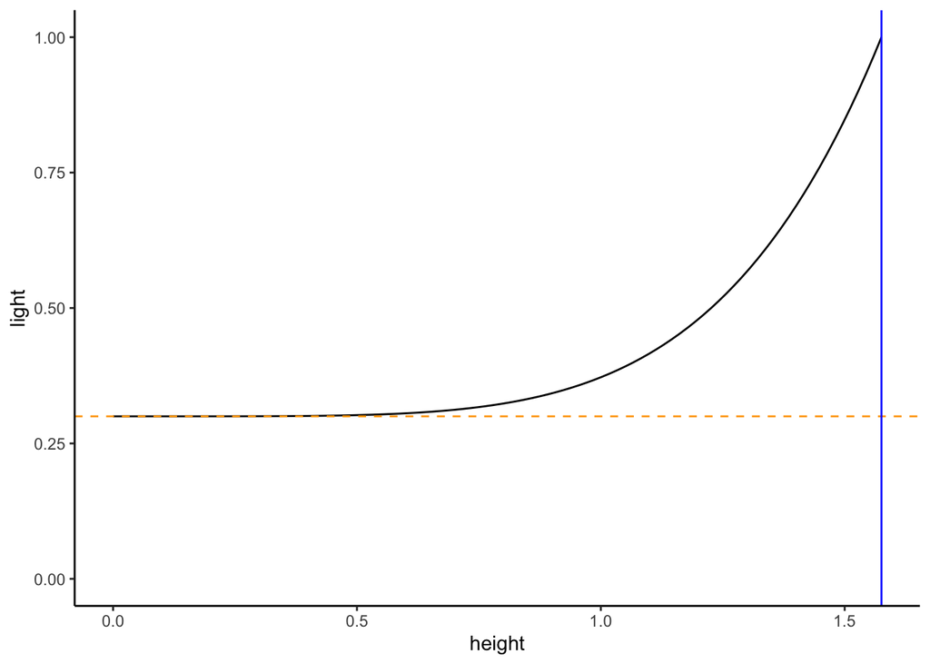

## 3.3 Equilbrium Density impact on Light Level